# Introduction to Quarto

Author

Affiliation

Carolina Torreblanca

University of Pennsylvania

Published

February 1, 2026

# What is Quarto?

Quarto is a publishing system that lets you combine text, code, and output into a single document.

**Why use Quarto?**

- Write analysis and explanation in one place
- Code runs and updates automatically when you render
- Export to HTML, PDF, Word, slides, websites
- All your assignments will be `.qmd` files rendered to `.html`
- Your final project will be a Quarto website

**The workflow:**

1. Write text and code in a `.qmd` file
2. Click “Render” (or Ctrl+Shift+K)
3. Quarto runs your code and produces a polished document

# Quarto Basics

## The YAML Header

Every Quarto document starts with a YAML header between `---` marks:

```yaml
---
title: "My Analysis"
author: "Your Name"
date: today
format: html
---
```

This controls the document’s metadata and output format.

## Markdown Formatting

Quarto uses Markdown for text formatting:

- *italics* with `*italics*`
- **bold** with `**bold**`
- [links](https://quarto.org) with `[text](url)`
- Create sections with `#`, `##`, `###`

### Lists

Bullet points:

- First item
- Second item
- Third item

Numbered lists:

1. First step
2. Second step
3. Third step

### Math

Use LaTeX for equations. Inline math: $y = mx + b$

Display equations:

$$\bar{x} = \frac{1}{n} \sum_{i=1}^{n} x_i$$

### Images

Include images from your project folder:

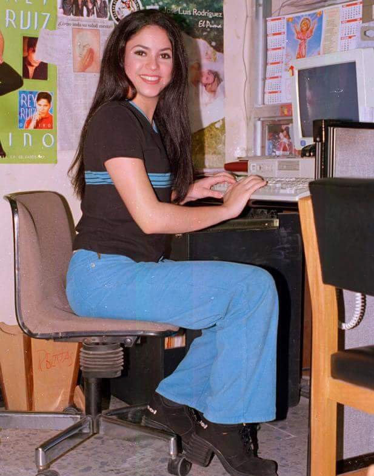

Shakira knows what’s up

```markdown
![Caption text](image.png){width="50%"}
```

### Tables

Create tables by hand:

| Column 1 | Column 2 | Column 3 |
| --- | --- | --- |
| A | B | C |
| D | E | F |

### Footnotes

Add footnotes like this.[^1]

# Code in Quarto

The real power of Quarto is integrating code with your writing.

## Code Chunks

Insert R code in “chunks” that look like this:

````markdown
```{r}
# Your R code here
mean(c(1, 2, 3, 4, 5))
```
````

When you render, the code runs and the output appears in your document.

## Example: Running Code

```r
# This code will run when you render
x <- c(10, 20, 30, 40, 50)
mean(x)
```

```
[1] 30
```

## Chunk Options

Control how chunks behave with options:

```
#| echo: true       # Show the code in output
#| echo: false      # Hide the code, show only results
#| eval: false      # Show code but don't run it
#| warning: false   # Suppress warning messages
#| message: false   # Suppress messages
```

## Example: Hidden Code

Sometimes you want to show results but hide the code:

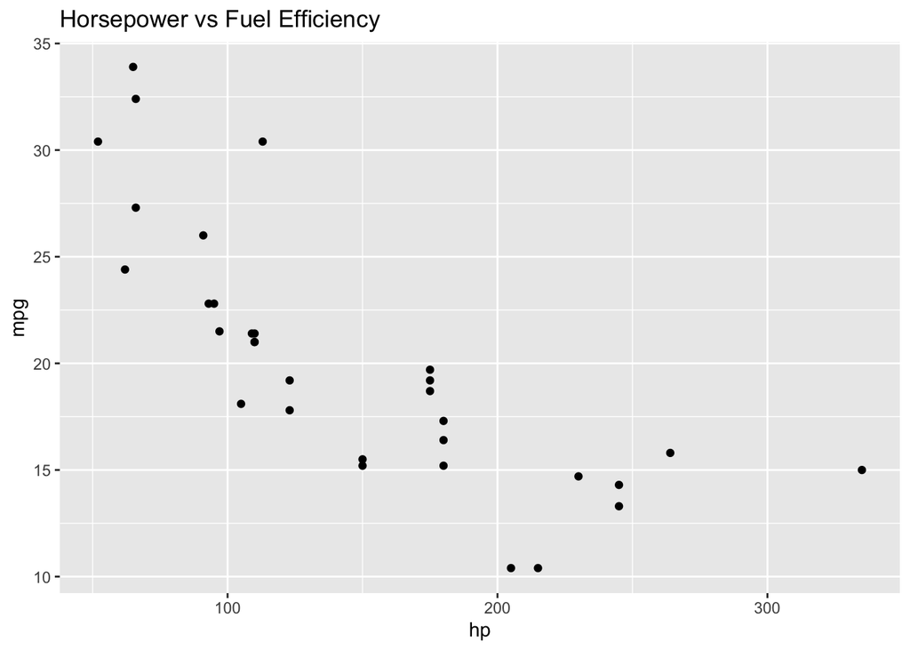

The plot appears, but readers don’t see the code that made it.

## Inline Code

Reference values directly in your text using inline code.

```r
n_cars <- nrow(mtcars)
avg_mpg <- round(mean(mtcars$mpg), 1)
```

Write: “The dataset contains `` `r n_cars` `` cars with an average fuel efficiency of `` `r avg_mpg` `` mpg.”

Result: The dataset contains 32 cars with an average fuel efficiency of 20.1 mpg.

If your data changes, these numbers update automatically!

# Figures and Tables

## Labeled Figures

Give figures labels and captions for cross-referencing:

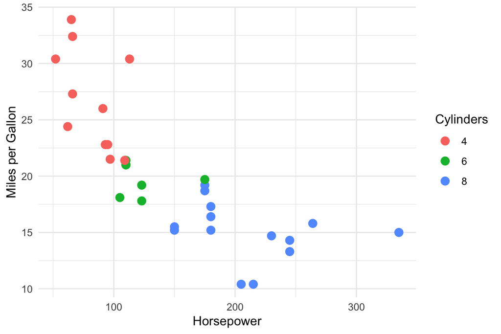

Figure 1: Relationship between horsepower and fuel efficiency

```r
ggplot(mtcars, aes(x = hp, y = mpg, color = factor(cyl))) +
  geom_point(size = 3) +
  labs(x = "Horsepower", y = "Miles per Gallon", color = "Cylinders") +
  theme_minimal()
```

Reference it in text with `@fig-scatter`: See Figure 1.

## Tables from Code

```r
library(dplyr)
mtcars %>%
  group_by(cyl) %>%
  summarize(
    `Average MPG` = round(mean(mpg), 1),
    `Count` = n()
  ) %>%
  knitr::kable()
```

Table 1: Average MPG by number of cylinders

| cyl | Average MPG | Count |
| --- | --- | --- |
| 4 | 26.7 | 11 |
| 6 | 19.7 | 7 |
| 8 | 15.1 | 14 |

Reference with `@tbl-summary`: See Table 1.

# Rendering Your Document

To create the final output:

1. **RStudio:** Click the “Render” button or press Ctrl+Shift+K
2. **Terminal:** Run `quarto render yourfile.qmd`

The output (`.html`, `.pdf`, etc.) appears in the same folder.

# Your Turn

1. Create a new `.qmd` file in RStudio (File → New File → Quarto Document)
2. Add a title and your name in the YAML header
3. Write a short paragraph using **bold** and *italics*
4. Add a code chunk that calculates something simple
5. Render to HTML and see the result

# Resources

- [Quarto Guide](https://quarto.org/docs/guide/)
- [Markdown Basics](https://quarto.org/docs/authoring/markdown-basics.html)
- [Code Chunks](https://quarto.org/docs/computations/r.html)

## Footnotes

[^1]: This is the footnote text.